# Testing STICS on Auzeville data

R. VEZY

14 juin, 2018

## Introduction

An experimentation was set on the fields of INRA at Auzeville for the years 2006, 2007, 2012 and 2013. The experimentation consisted in evaluating Wheat and Pea crops in:  
* sole crops at full density (resp. 280 and 60) or at half density (resp. 140 and 30)  
* mixed crops at half density (resp. 140 and 30)  
for different levels of nitrogen fertilization: 0, 100 and 180 kg ha-1 year-1.  
The [STICS](https://www6.paca.inra.fr/stics_eng/) model was run on the 5 types of crops (sole*4 + mixed) and the evaluation of the model is made on different observed and simulated variables. Some are measured at field level, and some for each species in the field.

## Data import

The simulations are made and imported using the sticRs package. For exemple, the mixed crop simulations are run and imported using the `stics_eval` function (see code).

```r
library(sticRs)
sim_Wheat_Pea=
  stics_eval(dir.orig = file.path(Source_dir,"IC_Wheat_Pea"),
             dir.targ = file.path(Simulation_dir,"IC_Wheat_Pea"),
             stics = Sics_exe,
             obs_name =  obs_names[["Mixed"]],
             Out_var = c(Out_var_plant,Out_var_plot),plot_it = F)$outputs
```

## Wheat in sole crop

STICS was run for a wheat in sole crop

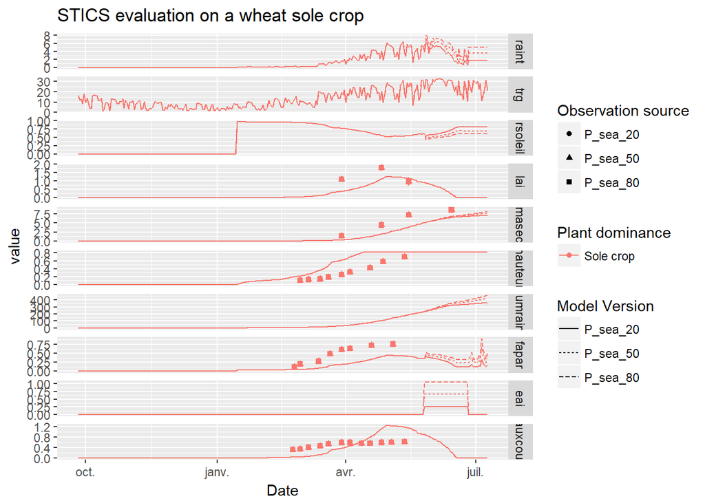

```r
sim_Wheat$gg_object+labs(title= "STICS evaluation on a wheat sole crop")
```

## Wheat in self-intercroping (Wheat-Wheat)

STICS was run for wheat in intercropping with wheat. This is a test to evaluate the model response using a zero hypothesis for intercropping (self-intercroping). Ideally, the model gives the closest outputs compared to a run in sole crop.

The wheat planting density was set to half the full density (=140), and the observations in the plots are from an experimentation in full density of a sole crop. The observed above-ground dry mass `masec` was divided by two fo comparison, because we expect half the total observed `masec` for the principal wheat, and half the `masec` for the associated wheat.

### Evaluation at field scale

Here is an evaluation of the STICS model using measurements at field scale:

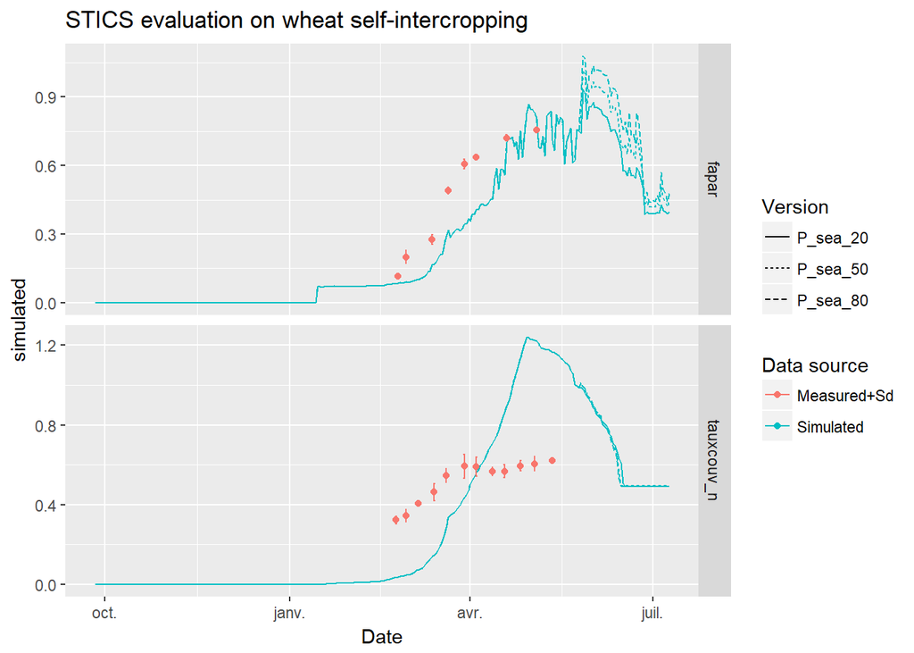

```r
plot_output_plant(x= sim_Wheat_Wheat,Title= "STICS evaluation on wheat self-intercropping")
```

### Evaluation for each crop “species” from the same field

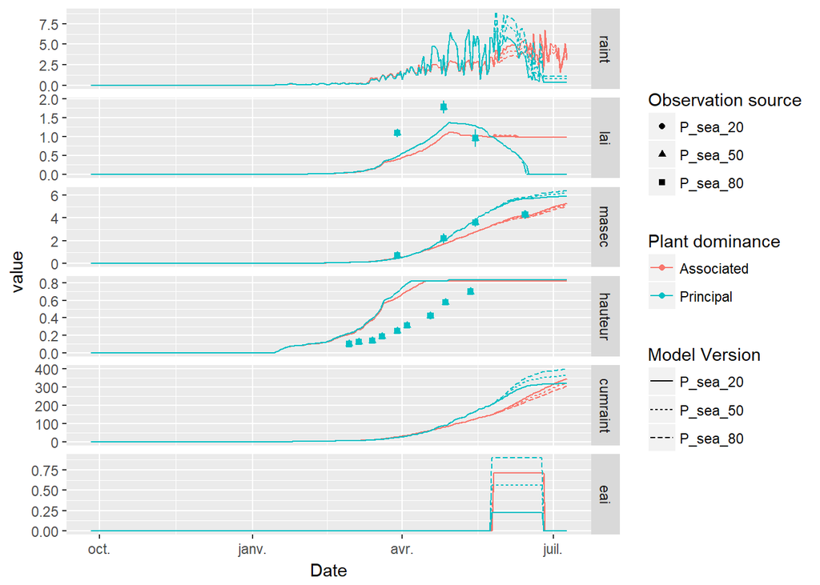

```r
sim_Wheat_Wheat[["Vars"]]= Out_var_plant
do.call(sticRs::plot_output,sim_Wheat_Wheat)
```

## Pea in sole crop

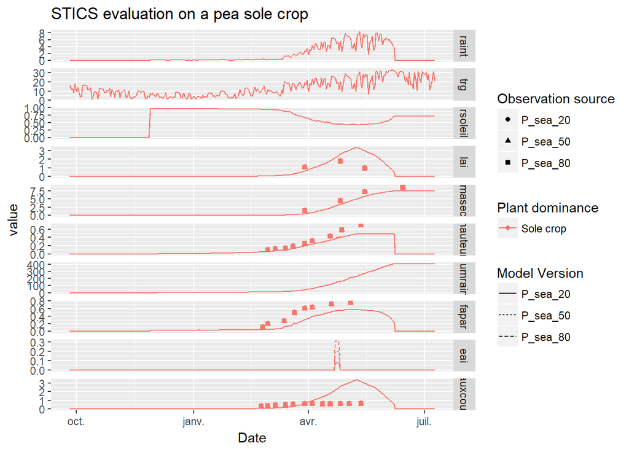

```r
sim_Pea$gg_object+labs(title= "STICS evaluation on a pea sole crop")
```

## Pea in self-intercropping (Pea-Pea)

STICS was run for pea in intercropping with pea. This is a test to evaluate the model response using a zero hypothesis for intercropping (self-intercroping). Ideally, the model gives the closest outputs compared to a run in sole crop.

The pea planting density was set to half the full density (=30), and the observations in the plots are from an experimentation in full density of a sole crop. The observed above-ground dry mass `masec` was divided by two fo comparison, because we expect half the total observed `masec` for the principal pea, and half the `masec` for the associated pea.

### Evaluation at field scale

Here is an evaluation of the STICS model using measurements at field scale:

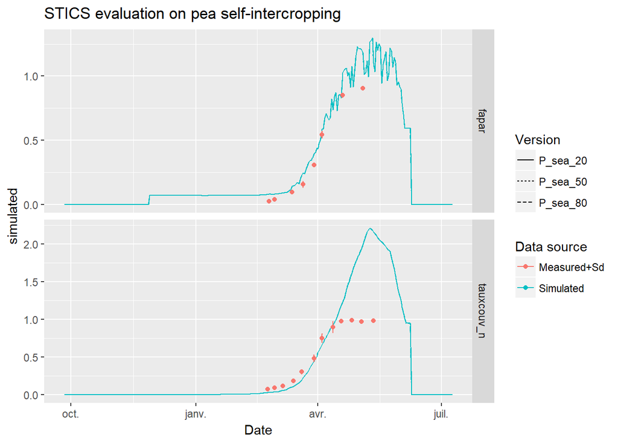

```r
plot_output_plant(x= sim_Pea_Pea,Title= "STICS evaluation on pea self-intercropping")
```

### Evaluation for each crop “species” from the same field

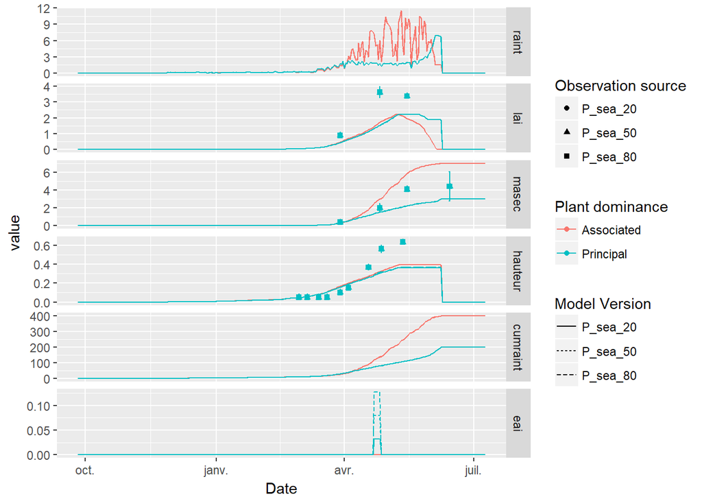

```r
sim_Pea_Pea[["Vars"]]= Out_var_plant
do.call(sticRs::plot_output,sim_Pea_Pea)
```

## Wheat and Pea in intercropping

### Evaluation at field scale

Here is an evaluation of the STICS model using measurements at field scale:

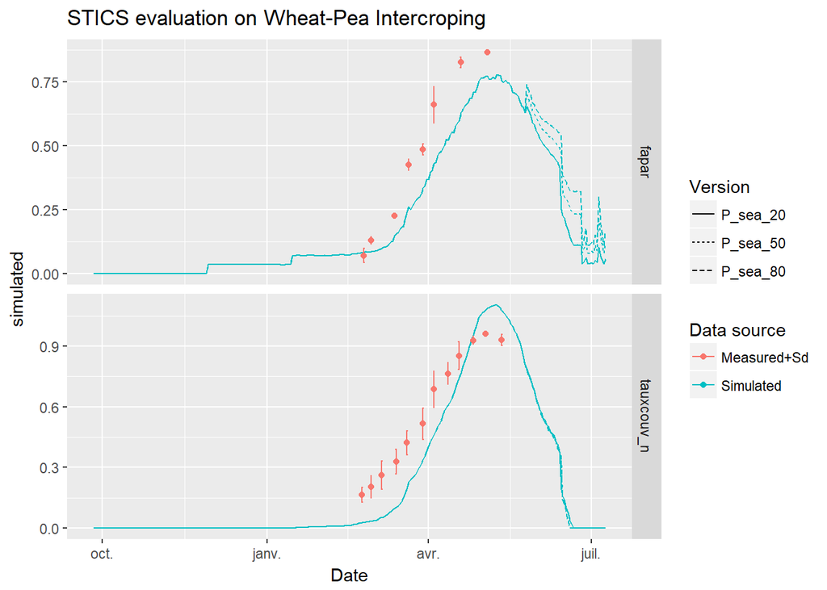

```r
plot_output_plant(x= sim_Wheat_Pea,Title= "STICS evaluation on Wheat-Pea Intercroping")
```

### Evaluation for each crop species from the same field

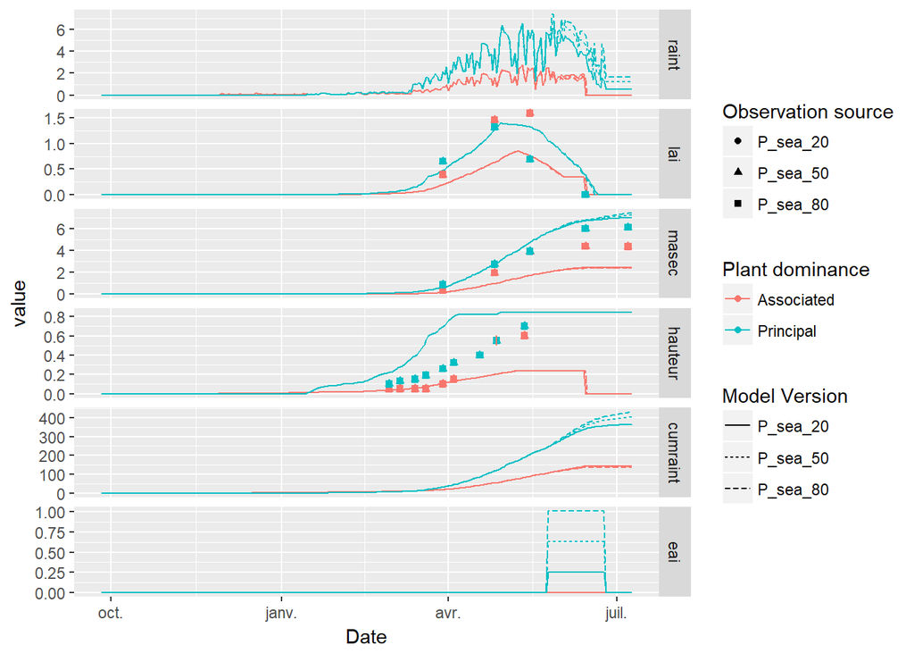

```r
sim_Wheat_Pea[["Vars"]]= Out_var_plant
do.call(sticRs::plot_output,sim_Wheat_Pea)
```